# Before you buy Bitcoin

## Investigation Overview

In this investigation, I wanted to look at the things to understand about Bitcoin before making an investment. The main focus was on the four variable: **market cap**, **volume**, **date**, **yearly-quarters**.

## Dataset Overview

The data consisted of historical daily market data of Bitcoin from 2013 - 2019. The original dataset contained the historical market data of the top ten cryptocurrencies from 2013 - 2019. I had to cut out only the Bitcoin data for the purpose of my investigation. No duplicate records and zero price points were removed (if any) . The dataset was downloaded from [Kaggle](https://www.kaggle.com/datasets/philmohun/cryptocurrency-financial-data).

## Distribution of Bitcoin Price

Price frequent more below 7,500 USD. Values above 12,500 USD have extremely low occurence. The price of Bitcoin peak highly below 2,500 USD, it will highly risky to purchase Bitcoin at a price above 2,500 USD.

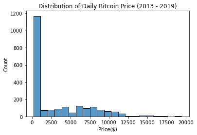

## Distribution of Bitcoin Market Cap

The distribution of Bitcoin Market Cap is biomodal. The market cap peak between 500 to 1k and peak a little above 10K. Low points at the center between 2K to 5K and also a little above 20k.

PS: The original market cap are in billions, so I had to define a scale from 500 to 20,000.

[figure not shown]

## Price follows Market Cap

Experience Crypto Investors use **market cap** to tell a more complete story and compare value across cryptocurrencies. As a key statistic, it can indicate the growth potential of a cryptocurrency and whether it is safe to buy, compared to others.

This visualization confirms that for Bitcoin. As the market cap increase, the price also increases over the years.

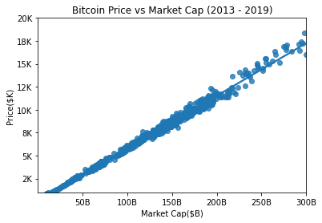

## Price follows trading volume (but..)

**Trading volume** is the amount of buy and sell order in the bitcoin market.

The more people buy and sell bitcoin, the price tend to increase. But, trading volume is not a good key indicator for understanding crypto price as much as **market cap**, as not all trades are **buy** orders. If there more people are selling their Bitcoin, the price will eventually go down and may result to a crash.

Rather use the Trading Volume to measure the level of activities going on in the Bitcoin market.

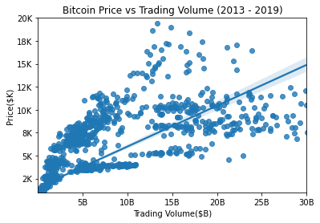

## Bitcoin is a long term game

**The price of Bitcoin perform better overall over the years**. However, looking at it short term performance(every 3 months), there are multiple ups and downs and they are hard to predict or measure. Also, it will interest you to note that in every upward movements there is a downward spiral that follows (vis-a-vis), although it will be hard to figure if the next move will be up or down and when it will happen.

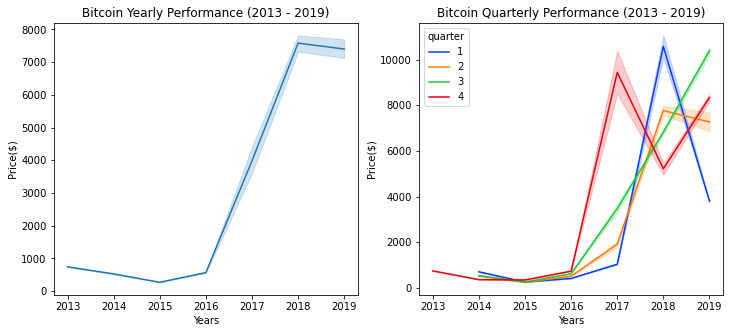

## Disclaimer

This is not an investment advice or solication to buy Bitcoin or any other crypto assets. This report was done only for educational purposes.